# MLB Game Statistics

**Names**:

Trevor Doucet and Andrew Selius

**GitHub Project Website:**

https://trevordoucet.github.io/baseball/

**Project Description:**

Our project aims to look at MLB pitching data in order to find relationships between the various features that coexist between a pitcher's technique and strategy, as well as the attributes that best predict a strike in the major leagues. We will be focusing on variables related to, but not limiteed to: a pitcher's release position, spin rate, zone location, and the hitter's outcome.

**Questions that we attend to address with Machine Learning and Statistical Analysis:**

- What are the most prominent features that predict a strike?
- Can we identify a pitcher that excels with these features?
- What pitchers best resemble this identified pitcher?

**Dataset**

Our primary dataset will come from https://baseballsavant.mlb.com/. This website provides official and comprehensive data from all MLB games. The main challenges we faced involved the manual process for downloading the raw csv files.

The secondary dataset will come from https://databases.usatoday.com/major-league-baseball-salaries-2023/. The plan will be to webscrape the tables containing contract information as baseball salaries are difficult to obtain casually.

**Project Coordination** Since two people are involved in this project, our collaboration plan is as follows:

- Weekly meetings and working sessions over Google Meets.
- Whatsapp communication for updates and meeting coordination.
- GitHub repository to coordinate code updates and version control.

## Imports

```python
# Dataframes
import pandas as pd
import numpy as np

# Visuals
import matplotlib.pyplot as plt
from matplotlib.lines import Line2D
import seaborn as sns

# Sklearn
from sklearn.model_selection import train_test_split
from sklearn.ensemble import RandomForestClassifier
from sklearn.metrics import classification_report, accuracy_score
from sklearn.metrics import confusion_matrix, ConfusionMatrixDisplay
from sklearn.tree import plot_tree
from sklearn.preprocessing import StandardScaler
from sklearn.neighbors import NearestNeighbors
from sklearn.decomposition import PCA
from sklearn.model_selection import learning_curve

# Web Scraping
from selenium import webdriver
from selenium.webdriver.common.by import By
from selenium.webdriver.support.ui import WebDriverWait
from selenium.webdriver.support import expected_conditions as EC
import time
```

## Datasets

### Baseball Savant

This dataset's instances are pitches and their outcomes, taking place between September and October of 2023. There are 94 columns that describe where the pitch took place, who threw the pitch, the pitch's attributes, and much more. There are a total of 25,000 rows and 430 unique pitchers nested throughout.

```python
df = pd.read_csv('../raw Data/savant_data.csv')

# Columns desired for the analysis
df = df[['player_name', 'pitch_type', 'pitch_name', 'release_speed',
           'game_date', 'release_spin_rate', 'description',
           'events', 'hit_distance_sc', 'pitch_number', 'strikes', 'balls', 'home_team', 'away_team', 'inning', 'outs_when_up', 'type',
           'zone', 'spin_axis', 'effective_speed', 'at_bat_number', 'release_pos_y', 'release_extension']]
```

### USA Today: Major League Baseball Salaries 2023

**Selenium as the main package**

This dataset's instances are MLB pitcher's contract details. The key package for this webscrape is called Selenium. Selenium is used by web developers for pressure testing, but has also found a place in the webscraping community.

**Using a Mac**

Our implementaion works with Safari as the main webdriver. If you want to run the below code and you have a mac: go to settings > advanced > show features for web developers (check box at the bottom) > developer > select "Allow remote automation" under automation.

**How it works**

The driver will load the desired website into a new Safari window. The code will then extract each table's information, append the details to a list, then find and click the "next" buttom. These operations work in a while loop and will continue until the last page has been reached. The whole process takes approximately 5 minutes

```python
# Set up Safari WebDriver
driver = webdriver.Safari()

# USA Today: Major League Baseball Salaries 2023
url = "https://databases.usatoday.com/major-league-baseball-salaries-2023/"
driver.get(url)

players = []

# Loop to go through all pages
while True:
    try:
        # Wait for the data table to load
        table = WebDriverWait(driver, 10).until(
            EC.presence_of_element_located((By.CLASS_NAME, "csp-data"))
        )

        # Extract rows from the current page
        rows = table.find_elements(By.TAG_NAME, "tr")
        for row in rows:
            cols = row.find_elements(By.TAG_NAME, "td")
            player_data = [col.text.strip() for col in cols]
            players.append(player_data)

        # Find and click the "Next" button
        next_button = WebDriverWait(driver, 10).until(
            EC.element_to_be_clickable((By.LINK_TEXT, "Next"))
        )
        next_button.click()

        # Wait for a short while to ensure the page loads
        time.sleep(3)

    except Exception as e:
        print("An error occurred or no more pages:", e)
        break

# Print the results
for player in players:
    print(player)

# Close the browser
driver.quit()

# DataFrame
scraped = pd.DataFrame(players)

# Export as a backup if you run this - use complete "salaries.xlsx"
scraped.to_excel('salaries_copy.xlsx')
```

### Preparing Data After Export

As the data comes in unformatted, somewhat uncomplete, and contains speciall case scenarios where a '(*)' is appended to certain players, we have to prepare and clean the data before implementation. This dataset should only be used for supplmentary purposes. The values will not be used for an extensive analysis on salaries.

```python
salaries_df = pd.read_excel('../raw Data/salaries.xlsx')

# Remove first row
salaries_df = salaries_df.iloc[1:]

# Drop previous index
salaries_df.drop(columns=['Unnamed: 0'], inplace=True)


# Drop rows that are completely empty
salaries_df.replace("", None, inplace=True)
salaries_df = salaries_df.dropna(how='all')

# Rename headers
new_headers = ['Player', 'Team', 'Position', 'Salary', 'Contract Years', 'Total Contract Value']
salaries_df.columns = new_headers

# Drop rows where Salary is equal to $0 (empty rows)
salaries_cleaned_df = salaries_df.loc[salaries_df['Salary'] != '$0']

# Numeric salary column
salaries_df['Numeric Salary'] = (
    salaries_df['Salary']
    .replace('[\$,]', '', regex=True)
    .astype(float)
)

# Remove '*' at the end of some names
salaries_df['Player'] = salaries_df['Player'].str.rstrip('*')
```

## Exploratory Data Analysis

### EDA 1: Pitch Quantity by Pitch Type

Here we will classify the dataset by the popularity of the type of pitch thrown. Pitches with total instances over 1000 will be placed into a separate dataframe, as will pitches below that 1000-count threshold.

```python
pitches_amount = df.groupby('pitch_name').size().to_frame('Total Pitches').reset_index()
```

```python
more_popular = pitches_amount[pitches_amount['Total Pitches'] >= 1000]
less_popular = pitches_amount[pitches_amount['Total Pitches'] < 1000]
```

### Bar Plot of Pitch Amounts by Pitch Type

Below are bar charts depicting pitch type frequencies. In order to better represent the data, we split the dataset into "more common" and "less common" pitch types based on the criteria mentioned above.

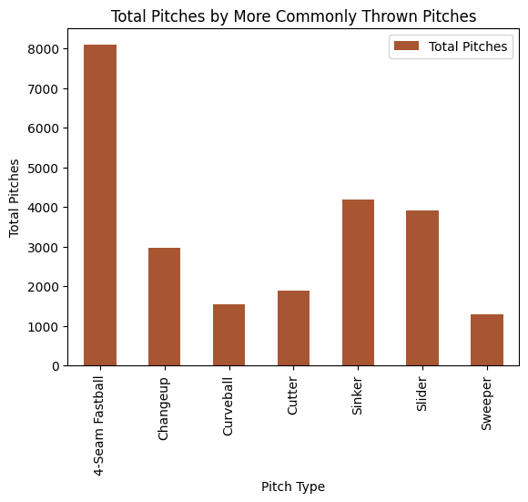

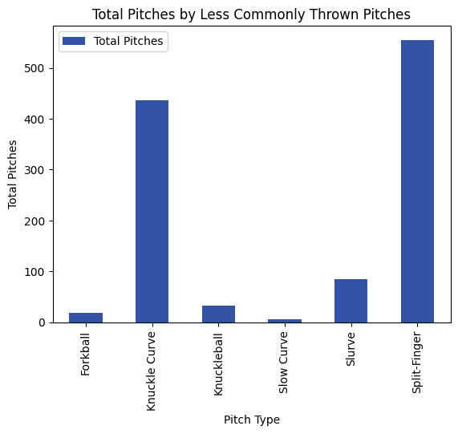

```python
more_popular.plot.bar(x ='pitch_name', y ='Total Pitches', color='#a85632')

plt.xlabel('Pitch Type')
plt.ylabel('Total Pitches')
plt.title('Total Pitches by More Commonly Thrown Pitches')
plt.show()

less_popular.plot.bar(x ='pitch_name', y ='Total Pitches', color='#3252a8')

plt.xlabel('Pitch Type')
plt.ylabel('Total Pitches')
plt.title('Total Pitches by Less Commonly Thrown Pitches')
plt.show()
```

**Takeaways:**

- The most popular pitch thrown in this dataset is the 4-Seam Fastball. Sinker and Slider follow behind at half the amount thrown.
- The least popular pitch thrown is the Slow Curve, with the Forkball being used a couple times more.

### EDA 2: Top Pitch Type Thrown In Each Stadium

Shown below is a summary of pitch types thrown in MLB stadiums, visualizing a different distribution of pitches thrown per stadium.

```python
df.groupby(['home_team', 'pitch_name']).size().to_frame('Pitch_Amounts').sort_values(by=['home_team', 'Pitch_Amounts'], ascending=False).head(50)
```

| home_team | pitch_name | Pitch_Amounts |
| --- | --- | --- |
| WSH | 4-Seam Fastball | 315 |
|  | Sinker | 157 |
|  | Slider | 138 |
|  | Changeup | 96 |
|  | Curveball | 56 |
|  | Knuckle Curve | 43 |
|  | Cutter | 35 |
|  | Sweeper | 8 |
|  | Split-Finger | 3 |
| TOR | 4-Seam Fastball | 258 |
|  | Sinker | 166 |
|  | Slider | 122 |
|  | Changeup | 87 |
|  | Curveball | 77 |
|  | Split-Finger | 64 |
|  | Cutter | 51 |
|  | Slurve | 20 |
|  | Sweeper | 15 |
| TEX | 4-Seam Fastball | 142 |
|  | Slider | 126 |
|  | Sinker | 120 |
|  | Changeup | 82 |
|  | Curveball | 79 |
|  | Cutter | 45 |
|  | Split-Finger | 41 |
|  | Knuckle Curve | 3 |
| TB | 4-Seam Fastball | 278 |
|  | Sinker | 144 |
|  | Cutter | 124 |
|  | Slider | 106 |
|  | Curveball | 78 |
|  | Sweeper | 47 |
|  | Split-Finger | 37 |
|  | Changeup | 31 |
| STL | 4-Seam Fastball | 312 |
|  | Slider | 135 |
|  | Sinker | 118 |
|  | Curveball | 79 |
|  | Sweeper | 70 |
|  | Changeup | 55 |
|  | Cutter | 32 |
|  | Split-Finger | 3 |
| SF | 4-Seam Fastball | 201 |
|  | Sinker | 178 |
|  | Slider | 155 |
|  | Changeup | 150 |
|  | Split-Finger | 43 |
|  | Sweeper | 41 |
|  | Knuckle Curve | 34 |
|  | Slurve | 24 |

**Takeaways:**

- As potrayed by the graphs above, we can notice the same pattern of total pitches thrown at each stadium. Cutter takes the third most frequent title at Tampa Bay's stadium.

### EDA 3: Total Pitches Thrown In A Single Game

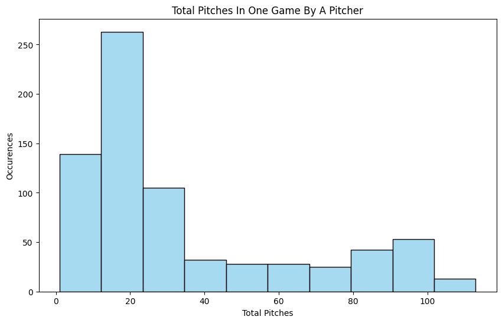

```python
total_pitches_df = df.groupby(['player_name', 'game_date']).size().to_frame('Total Pitches')

plt.figure(figsize=(10, 6))
sns.histplot(total_pitches_df['Total Pitches'], bins=10, kde=False, color='skyblue')

plt.xlabel('Total Pitches')
plt.ylabel('Occurences')
plt.title('Total Pitches In One Game By A Pitcher')
plt.show()
```

**Takeaways:**

- The total pitches in one game by a pitcher histogram appears to be right-skewed, indicating that there are not many games in this dataset where a pitcher will throw more than 40 pitches in a single game.
- The most common amount of pitches thrown in a game falls in the range of approximately 10-20 pitches.
- There are more occurences of pitchers throwing 80-100 pitches than 40-60.

### Interesting Stat

```python
ffast_sr = round(df[df['pitch_name'] == '4-Seam Fastball']['release_spin_rate'].mean(), 2)
curv_sr = round(df[df['pitch_name'] == 'Curveball']['release_spin_rate'].mean(), 2)


print(f'Average 4-Seam Fastball spin rate is {ffast_sr} rpm')
print(f'Average Curveball spin rate is {curv_sr} rpm')
print('\n')
print(f"An average Curveball's spin rate is {round(curv_sr - ffast_sr, 2)} faster than the spin rate of a 4-Seam Fastball")
```

```
Average 4-Seam Fastball spin rate is 2268.28 rpm
Average Curveball spin rate is 2517.66 rpm


An average Curveball's spin rate is 249.38 faster than the spin rate of a 4-Seam Fastball
```

#### EDA 4: Spin Rate Over The Course of a Game

Selecting two high pitch count games, we aim to display any changes in the spin rate over the course of a single MLB game. Our assumption is that as the game progresses, spin rate will decrease.

```python
top_pitch_games = total_pitches_df[total_pitches_df['Total Pitches'] > 90].reset_index()
top_pitch_games.sort_values(by='Total Pitches', ascending=False).head(5)
```

|  | player_name | game_date | Total Pitches |
| --- | --- | --- | --- |
| 41 | Peterson, David | 2023-09-28 | 113 |
| 7 | Canning, Griffin | 2023-09-27 | 111 |
| 64 | Webb, Logan | 2023-09-25 | 110 |
| 10 | Cole, Gerrit | 2023-09-21 | 107 |
| 1 | Bassitt, Chris | 2023-09-28 | 106 |

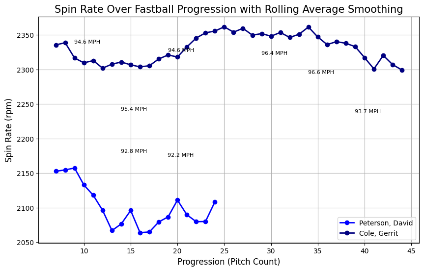

```python
player_1 = 'Peterson, David'
player_2 = 'Cole, Gerrit'
pitches = ['4-Seam Fastball', 'Curveball']

two_hp_games = df[(df['player_name'].isin([player_1, player_2])) & (df['game_date'].isin(['2023-09-28', '2023-09-21']))]

player_1_df = two_hp_games.query(f'player_name == "{player_1}"')
player_2_df = two_hp_games.query(f'player_name == "{player_2}"')


# Sorting for innings and outs, so a progression series can be constructed.
innings_outs_sorted_1_df = player_1_df.sort_values(by=['inning', 'outs_when_up'])
f_seams_1_df = innings_outs_sorted_1_df.query('pitch_name == "4-Seam Fastball"')

innings_outs_sorted_2_df = player_2_df.sort_values(by=['inning', 'outs_when_up'])
f_seams_2_df = innings_outs_sorted_2_df.query('pitch_name == "4-Seam Fastball"')

# Create copies of the slices to avoid warnings
f_seams_p1_df = f_seams_1_df.copy()
f_seams_p2_df = f_seams_2_df.copy()

f_seams_p1_df.loc[:, 'progression'] = range(1, len(f_seams_p1_df) + 1)
f_seams_p2_df.loc[:, 'progression'] = range(1, len(f_seams_p2_df) + 1)

# Concat both games
concat_two_games = pd.concat([f_seams_p1_df, f_seams_p2_df])

# Plot
plt.figure(figsize=(10, 6))

color_dict = {
    player_1 : 'blue',
    player_2: 'navy'
}

for player in concat_two_games['player_name'].unique():
    player_data = concat_two_games[concat_two_games['player_name'] == player]
    # Rolling window set to 7 pitch average
    plt.plot(player_data['progression'], player_data['release_spin_rate'].rolling(window=7).mean(),  marker='o', color=color_dict[player], linestyle='-', linewidth=2, label=player)

    # Annotations for release speed
    for i, row in player_data.iterrows():
        if row['progression'] % 5 == 0: # every 5th pitch
            plt.annotate(f"{row['release_speed']:.1f} MPH",
                         (row['progression'], row['release_spin_rate']),
                         textcoords="offset points",
                         xytext=(5, 10),
                         ha='center', fontsize=8)

plt.xlabel('Progression (Pitch Count)', fontsize=12)
plt.ylabel('Spin Rate (rpm)', fontsize=12)
plt.title('Spin Rate Over Fastball Progression with Rolling Average Smoothing', fontsize=15)
plt.grid(True)
plt.legend()
plt.show()
```

**Takeaways:**

- The graph indicates that each pitcher had a unique reliance on their fastball. Gerrit Cole used his 4-Seam Fastball for approximately half of his total pitches while maintaining a consistent spin rate. David Peterson threw his fastball for around 25% of his total pitches thrown against the Miami Marlins.
- This fact coupled with David's spin rate is noticably less than Gerrit's, we can assume that David Peterson likes to throw the off-speed more than Gerrit, at least that's what happened in these two game specific scenarios.

### EDA 5: Salary Distribution by Position

The code below takes user input as a filter to visualize a distribution of salaries by position. The salaries represent single season, not total contract value.

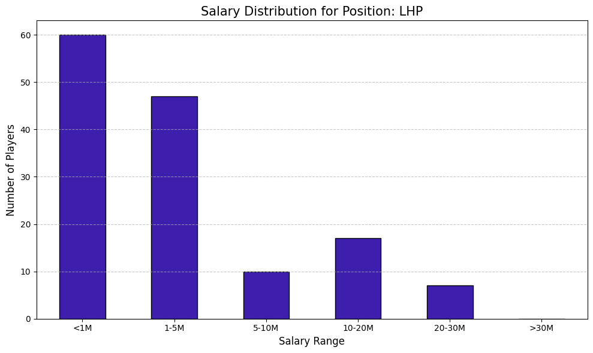

```python
# Input
position_pref = input(f'Select a position (e.g.: RHP, OF, 3..)')

# Filter based on input
filtered_df = salaries_df[salaries_df['Position'] == position_pref]

# Bin for distribution
bin_edges = [0, 1000000, 5000000, 10000000, 20000000, 30000000, 50000000]
bin_labels = ['<1M', '1-5M', '5-10M', '10-20M', '20-30M', '>30M']
filtered_df = filtered_df.copy()
filtered_df['Salary Range'] = pd.cut(filtered_df['Numeric Salary'], bins=bin_edges,
                                         labels=bin_labels, right=False)
# Plot histogram
plt.figure(figsize=(10, 6))
salary_counts = filtered_df['Salary Range'].value_counts(sort=False)
bars = salary_counts.plot(kind='bar', color='#3e1fad', edgecolor='black')
plt.title(f'Salary Distribution for Position: {position_pref}', fontsize=15)
plt.xlabel('Salary Range', fontsize=12)
plt.ylabel('Number of Players', fontsize=12)
plt.xticks(rotation=0)
plt.grid(axis='y', linestyle='--', alpha=0.7)

plt.tight_layout()
plt.show()
```

**Takeaways:**

- Majority of players in this dataset are paid under $1 milliion dollars where there are fery few, highlighy valued players paid over $30 million in one single season.

## Machine Learning Chosen: Random Forest

**Why Random Forest**

The Random Forest algorithm handles one-hot encoded categorical features effectively and does not require feature scaling, making it easy to integrate mixed data types. Random Forest supports balancing class weights which we found helpful for fine tuning the dataset's imbalance of strikes and balls. Resampling techniques were available to be applied to create equal samples in training, ensuring the model performs well for both classes.

**Inputs:**

The features we chose are a mix of categorical features and quanatative features. We chose what features we believed to be most important and decided to include a comprehensive list to reduce bias, knowing variability would be an obstacle.

The categorical features we chose to one-hot encode:

'pitch_number', 'outs_when_up', 'inning', 'strikes', 'balls', 'at_bat_number', 'zone'

The quantitative features used:

'release_speed', 'release_spin_rate', 'effective_speed', 'release_pos_y', 'release_extension', 'spin_axis'

**Assumptions**:

Important inputs that we added to the RandomForestClassifier function was limiting the max depth and min samples split to 10 and 5, respectively. Shallower trees require fewer splits and nodes, reducing the computational cost for both training and inference. This prevented overfitting and reduced noise sensitivity which we found necessary given the large number of features chosen

**Performance**:

Overall the model's performance was satisfactory with an **81% accuracy**, **95% precision** on strikes, **95% recall** for balls, and a macro average F1-score of **0.81**.

```
Random Forest Classification Report
              precision    recall  f1-score   support

           0       0.95      0.71      0.81      2364
           1       0.71      0.95      0.82      1797

    accuracy                           0.81      4161
   macro avg       0.83      0.83      0.81      4161
weighted avg       0.85      0.81      0.81      4161



Model Accuracy: 0.81
```

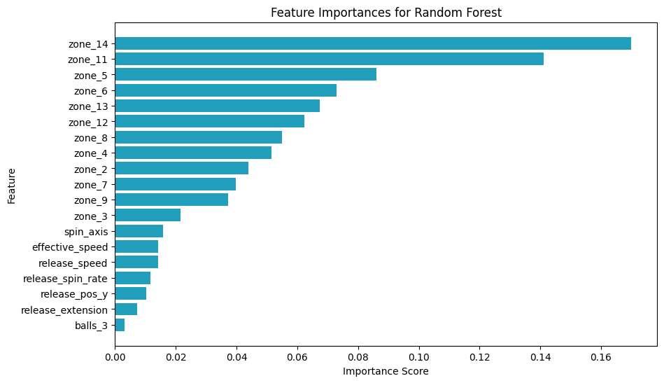

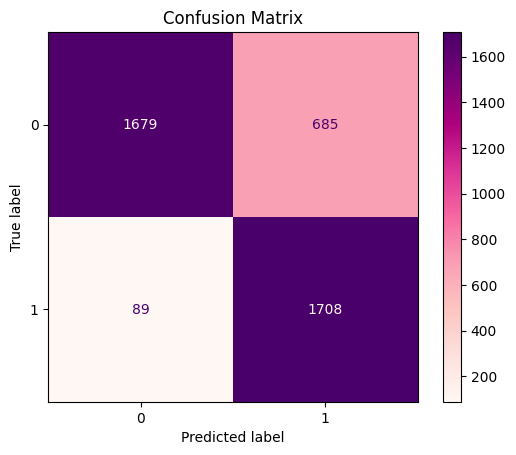

```python
# New dataframe for model testing
data = df[['type', 'pitch_number', 'outs_when_up', 'inning', 'release_speed', 'release_spin_rate',
           'strikes', 'balls', 'spin_axis', 'effective_speed', 'at_bat_number', 'zone', 'effective_speed', 'release_pos_y', 'release_extension']]

# Only test for strikes and balls, not hit in play (X)
test_models_df = data[data['type'].isin(['S', 'B'])].copy()

# Encode the target variable
test_models_df['type'] = test_models_df['type'].map({'S': 0, 'B': 1})

# Features
scenario_features = ['pitch_number', 'outs_when_up', 'inning', 'strikes', 'balls', 'at_bat_number', 'zone']
quantitative_features = ['release_speed', 'release_spin_rate', 'effective_speed', 'release_pos_y', 'release_extension', 'spin_axis']

# Transform for one-hot
for col in scenario_features:
    test_models_df[col] = test_models_df[col].astype('category')

# One-hot encode categorical features
categorical_encoded = pd.get_dummies(test_models_df[scenario_features], drop_first=True)

# Combine encoded categorical features with quantitative
features = pd.concat([categorical_encoded, test_models_df[quantitative_features]], axis=1)
target = test_models_df['type']

# Split the dataset
X_train, X_test, y_train, y_test = train_test_split(features, target, test_size=0.2, random_state=42)

# Create equal samples from both classes
y_train_class_1_count = y_train.value_counts()[1]
S_train = X_train[y_train == 0].sample(y_train_class_1_count, random_state=42)
B_train = X_train[y_train == 1]

# Concatenate resampled classes
X_train_resampled = pd.concat([S_train, B_train])
y_train_resampled = pd.concat([y_train[y_train == 0].sample(y_train_class_1_count, random_state=42),
                              y_train[y_train == 1]])

# Define Random Forest Model
randomf = RandomForestClassifier(max_depth=10, min_samples_split=5, random_state=42, class_weight='balanced')

# Trail the model
randomf.fit(X_train_resampled, y_train_resampled)

# Predictions
y_pred = randomf.predict(X_test)

# Accuracy
accuracy = accuracy_score(y_test, y_pred)

# Evaluation
print('\n')
print(f'Random Forest Classification Report')
print(classification_report(y_test, y_pred))
print('\n')
print(f'Model Accuracy: {accuracy:.2f}')

# Feature visualization
importances = randomf.feature_importances_
feature_names = features.columns
importance_df = pd.DataFrame({
    'Feature': feature_names,
    'Importance': importances
}).sort_values(by='Importance', ascending=True)

# Filtering for the top 10 most important features
top_10 = importance_df.sort_values(by='Importance', ascending=False).head(20)

# Plot
plt.figure(figsize=(10, 6))
plt.barh(top_10['Feature'], top_10['Importance'], color='#219ebc')
plt.gca().invert_yaxis()
plt.title('Feature Importances for Random Forest')
plt.xlabel('Importance Score')
plt.ylabel('Feature')
plt.show()

# Confusion matrix
cm = confusion_matrix(y_test, y_pred)

# Heatmap
disp = ConfusionMatrixDisplay(confusion_matrix=cm, display_labels=randomf.classes_)
disp.plot(cmap='RdPu', values_format='d')

plt.title('Confusion Matrix')
plt.show()
```

**Takeaways:**

- Zone is the dominant feature for this model with the top two zones being Zone 14 (low and outside on a right handed batter) and Zone 11 (high and in on a right handed batter).
- These locations are desired because, while technically in the 'ball' zone, they often result in strikes due to a combination of the catcher's framing skills, the batter's perception, and the umpire's judgement, making them a sweet spot for strikes.
- The confusion matrix depicts the model's weakness of predicting balls that are actually strikes.

## Model Evalutaion

The code below generates a learning curve for the Random Forest model to evalute performance across different training test sizes. The learning curve function computes training and validation accuracy scores for the model using a 5-fold cross-validation across varying proportions of the training data. The mean and standard deviation of the training and validation scores are calculated to assess the variability in performance across folds.

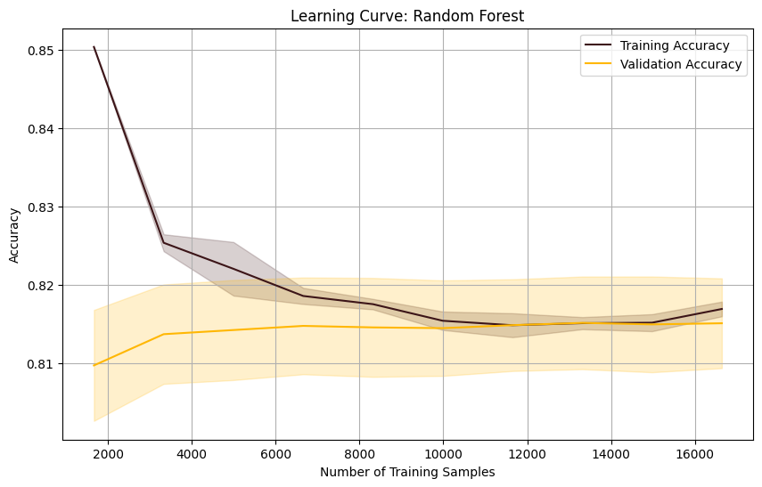

```python
# Learning curve data
train_sizes, train_scores, val_scores = learning_curve(
    estimator=randomf,
    X=features,
    y=target,
    cv=5, # 5-fold cross validation
    scoring='accuracy',
    n_jobs=-1,
    train_sizes=np.linspace(0.1, 1.0, 10) # 10 increments from 10% to 100% of the data
)

# Mean and standard deviation of scores
train_mean = np.mean(train_scores, axis=1)
train_std = np.std(train_scores, axis=1)
val_mean = np.mean(val_scores, axis=1)
val_std = np.std(val_scores, axis=1)

# Plot the learning curve
plt.figure(figsize=(10, 6))
plt.plot(train_sizes, train_mean, label='Training Accuracy', color='#3C1518')
plt.fill_between(train_sizes, train_mean - train_std, train_mean + train_std, color='#3C1518', alpha=0.2)
plt.plot(train_sizes, val_mean, label='Validation Accuracy', color='#ffb703')
plt.fill_between(train_sizes, val_mean - val_std, val_mean + val_std, color='#ffb703', alpha=0.2)

plt.title('Learning Curve: Random Forest')
plt.xlabel('Number of Training Samples')
plt.ylabel('Accuracy')
plt.legend(loc='best')
plt.grid()
plt.show()
```

**Takeaways:**

- The model performs well, with both training and validation accuracy converging at higher data sizes. The shaded regions' widths show low variability in training but moderate variability in validation. This was a likely outcome as we chose to reduce bias with the larger quantity of features chosen which comes at a risk of higher variability.

### Feature Analysis: Zone

As we have learned from our model, a pitch's location is a high contributor to predicting the final outcome. The final part of this notebook will be devoted to exploring the last two questions posed at the beginning:

- Can we identify a pitcher that excels with these features?
- What pitchers best resemble this identified pitcher?

The dataframe below will highlight which pitcher "owns" each zone and a pitch's attributed that contributed to that pitcher's success in their respective zone.

```python
# Strikes Only
strikes = df[df['type'] == 'S']

# Calculate the attributes for each pitch type and zone
attributes = strikes.groupby(['player_name', 'pitch_type', 'zone']).agg({
    'release_speed': 'mean',
    'release_spin_rate': 'mean',
    'spin_axis': 'mean',
    'type': 'size'
}).rename(columns={'type': 'strike_count'}).reset_index()

# Calculate the total strikes per pitch type to compute the strike percentage
total_strikes_per_pitch = attributes.groupby(['player_name', 'pitch_type'])['strike_count'].transform('sum')
attributes['strike_percentage'] = round((attributes['strike_count'] / total_strikes_per_pitch)  * 100, 2)
attributes[['release_speed', 'release_spin_rate', 'spin_axis']] = attributes[['release_speed', 'release_spin_rate', 'spin_axis']].round(2)

# Find the maximum strike count for each zone
max_strike_idx = attributes.groupby('zone')['strike_count'].idxmax()

# Retrieve corresponding rows
max_strike_rows = attributes.loc[max_strike_idx]

# Display
max_strike_rows
```

|  | player_name | pitch_type | zone | release_speed | release_spin_rate | spin_axis | strike_count | strike_percentage |
| --- | --- | --- | --- | --- | --- | --- | --- | --- |
| 720 | Brieske, Beau | FF | 1 | 97.29 | 2420.70 | 206.40 | 10 | 55.56 |
| 5410 | Sheehan, Emmet | FF | 2 | 94.27 | 2297.67 | 215.11 | 9 | 29.03 |
| 1129 | Cole, Gerrit | FF | 3 | 95.24 | 2338.88 | 209.12 | 8 | 30.77 |
| 4790 | Pérez, Martín | SI | 4 | 92.02 | 1911.88 | 130.12 | 8 | 26.67 |
| 1406 | Dodd, Dylan | FF | 5 | 92.64 | 2252.71 | 140.29 | 7 | 35.00 |
| 5117 | Rutledge, Jackson | FF | 6 | 95.86 | 2358.67 | 227.89 | 9 | 31.03 |
| 6124 | Ureña, José | SI | 7 | 94.60 | 2206.33 | 225.33 | 9 | 26.47 |
| 886 | Canning, Griffin | CH | 8 | 90.43 | 1957.00 | 231.43 | 7 | 43.75 |
| 460 | Bieber, Shane | FF | 9 | 91.07 | 2281.11 | 212.11 | 9 | 23.68 |
| 935 | Castillo, Luis | FF | 11 | 96.82 | 2263.56 | 234.89 | 9 | 19.57 |
| 5069 | Rom, Drew | FF | 12 | 92.15 | 2345.80 | 150.00 | 10 | 26.32 |
| 6128 | Ureña, José | SI | 13 | 95.12 | 2200.00 | 225.50 | 12 | 35.29 |
| 3678 | López, Pablo | ST | 14 | 85.15 | 2538.91 | 47.00 | 11 | 40.74 |

**Takeaways:**

- Though the pitch count is low due to a month's worth of data, these pitchers succeeded above all others in these zones with a certain pitch and displayed is the accompanying averages.

### Salary and Nearest Neighbors of Gerrit Cole

As Gerrit Cole scored the highest in zone 3 and we displayed one of his games earlier in the notebook, we will choose him for a salary comparison and the nearest neighbors example.

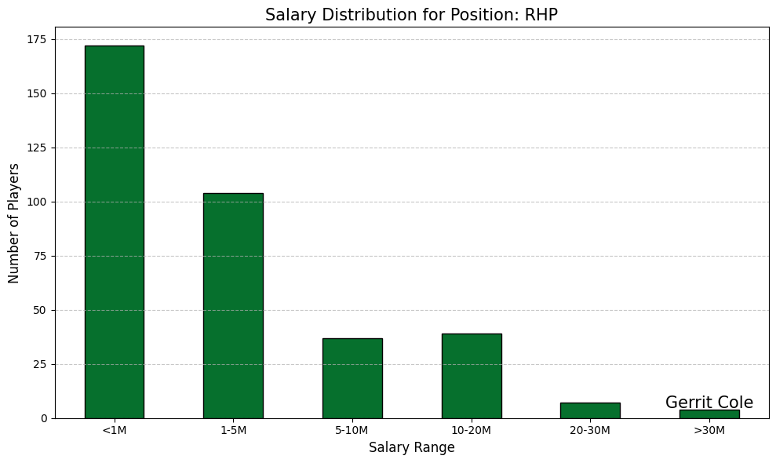

```python
filtered_df = salaries_df[salaries_df['Position'] == 'RHP']

bin_edges = [0, 1000000, 5000000, 10000000, 20000000, 30000000, 50000000]
bin_labels = ['<1M', '1-5M', '5-10M', '10-20M', '20-30M', '>30M']
filtered_df = filtered_df.copy()
filtered_df['Salary Range'] = pd.cut(filtered_df['Numeric Salary'], bins=bin_edges,
                                         labels=bin_labels, right=False)
# Plot histogram
plt.figure(figsize=(10, 6))
salary_counts = filtered_df['Salary Range'].value_counts(sort=False)
bars = salary_counts.plot(kind='bar', color='#06702d', edgecolor='black')
plt.title(f'Salary Distribution for Position: RHP', fontsize=15)
plt.xlabel('Salary Range', fontsize=12)
plt.ylabel('Number of Players', fontsize=12)
plt.xticks(rotation=0)
plt.grid(axis='y', linestyle='--', alpha=0.7)

# Gerrit Cole
for idx, count in enumerate(salary_counts):
    if salary_counts.index[idx] == '>30M':
        if salary_counts.index[idx] == '>30M':
            plt.text(idx, count + 0.5, 'Gerrit Cole', ha='center', fontsize=15, color='black')

plt.tight_layout()
plt.show()
```

**Takeaways:**

- As mentioned earlier, it is rare to have a one season payout of over $30 million dollars. No surprise here, but with Gerrit's experience in the game and his ability to control and maintain an effective fastball, the Yankees have valued him above majority of MLB pitchers.

### Nearest Neighbors

Our goal is to find pitchers that most resemble Gerrit Cole through mechanics, outcomes, and strategy

**Mechanics:**

- Release spin rate
- Release Position Y, s
- Spin axis

**Outcomes:**

- Hit Distance SC

```
Distances to Gerrit Cole's Neighbors
1. Cole, Gerrit: 0.0000
2. Phillips, Evan: 0.4164
3. Leone, Dominic: 0.6853
4. Heaney, Andrew: 0.7507
5. Woodford, Jake: 0.7858
```

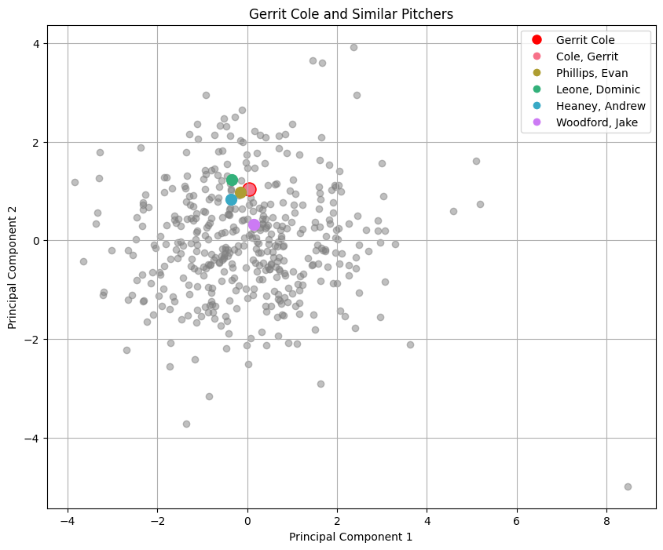

```python
# DF for NN
nn_df = df.copy()

# Custom mode function
def mode_agg(series):
    '''Mode of a pandas series'''
    return series.mode().iloc[0] if not series.mode().empty else None

# Aggregated metrics
aggregated_df = df.groupby('player_name').agg({
    'release_spin_rate': 'mean',
    'effective_speed': 'mean',
    'spin_axis': 'mean',
    'release_extension': 'mean',
    'release_pos_y': 'mean',
    'zone': mode_agg,
    'hit_distance_sc': 'mean'
}).dropna()

# Set player_name as index
aggregated_df = aggregated_df.reset_index().set_index('player_name')

# Player features
player_features = ['release_spin_rate', 'effective_speed', 'spin_axis',
                   'release_extension', 'release_pos_y', 'hit_distance_sc']

# Standardize the features
scaler = StandardScaler()
scaled_features = scaler.fit_transform(aggregated_df[player_features])

# Neighbors to Gerrit Cole
gerrit_cole_data = aggregated_df.loc[['Cole, Gerrit'], player_features]
scaled_gerrit_cole_data = scaler.transform(gerrit_cole_data)

# Fit NN Model
nn = NearestNeighbors(n_neighbors=5, metric='euclidean')
nn.fit(scaled_features)

# Closet neighbors to Gerrit Cole
distances, indices = nn.kneighbors(scaled_gerrit_cole_data)
neighbors_indices = indices[0]
# Player names
similar_players = aggregated_df.iloc[indices[0]]

# Reduce dimensions using PCA for visualizations
pca = PCA(n_components=2)
reduced_features = pca.fit_transform(scaled_features)
gerrit_cole_2d = pca.transform(scaled_gerrit_cole_data)

# Distinct colors for similar players
num_neighbors = len(neighbors_indices)
palette = sns.color_palette('husl', num_neighbors)

# Plot all players
plt.figure(figsize=(10, 8))
plt.scatter(reduced_features[:, 0], reduced_features[:, 1], color='grey', alpha=0.5, label='Other Players')

# Highlight Gerrit Cole
plt.scatter(gerrit_cole_2d[0, 0], gerrit_cole_2d[0, 1], color='red', label='Gerrit Cole', s=150)
gerrit_legend_label = Line2D([0], [0], marker='o', color='w', label='Gerrit Cole',
                             markerfacecolor='red', markersize=10)

# Similar players
similar_players_labels = []
for i, idx in enumerate(neighbors_indices):
    neighbors_2d = reduced_features[idx]
    player_name = aggregated_df.index[idx]
    player_color = palette[i]
    plt.scatter(neighbors_2d[0], neighbors_2d[1], color=player_color, s=100)
    # Custom legend
    legend_label = Line2D([0], [0], marker='o', color='w', label=player_name,
                          markerfacecolor=player_color, markersize=8)
    similar_players_labels.append(legend_label)

print("Distances to Gerrit Cole's Neighbors")
for i, idx in enumerate(indices[0]):
    neighbor_name = aggregated_df.index[idx]
    print(f"{i+1}. {neighbor_name}: {distances[0][i]:.4f}")


plt.legend(handles=[gerrit_legend_label] + similar_players_labels, loc='best')

# Labels
plt.title('Gerrit Cole and Similar Pitchers')
plt.xlabel('Principal Component 1')
plt.ylabel('Principal Component 2')
plt.grid(True)
plt.show()
```

**Takeaways:**

## Salary Comparison

```python
# Similar players dataframe from NN model
similar_players = similar_players.reset_index().copy()

# Names to list for filtering
players_list = similar_players['player_name'].tolist()

# Displayed dataframe
salaries_cleaned_df.loc[salaries_cleaned_df['Player'].isin(players_list)]
```

|  | Player | Team | Position | Salary | Contract Years | Total Contract Value |
| --- | --- | --- | --- | --- | --- | --- |
| 5 | Cole, Gerrit | N.Y. Yankees | RHP | $36,000,000 | 9.0 | $324,000,000 |
| 119 | Heaney, Andrew | Texas | LHP | $12,000,000 | 2.0 | $25,000,000 |
| 479 | Phillips, Evan | L.A. Dodgers | RHP | $1,300,000 | NaN | $0 |
| 627 | Woodford, Jake | St. Louis | RHP | $739,800 | NaN | $0 |

**Takeaways**: MLB teams tend to pay good pitchers well, but there is talent out there that can be found for a lower cost. The pitchers that perform at a similar level to Gerrit Cole may be undervalued, giving them a possible boost in salary at the end of their contracts.

## Conclusion

Based on our primary investigation, the most important factor of a pitch that results in a strike is the zone that it targets, moreso than other factors such as speed and spin rate. This indicates that pitchers that are successful in striking out batters are throwing towards a preferred zone.